# Modis Peru 2010-2015

# ANALISIS KORELASI PADA DATA FIRE MODIS MENGGUNAKAN PRINCIPAL COMPONENET ANALYSIS (STUDI KASUS: NEGARA PERU, TAHUN 2010-2015)

### Nama: Wahyu Dwi Prasetio

### NPM : G1A019010

### Tugas UAS Mata Kuliah Data Mining

```r
# install.packages("corrplot")
# install.packages("psych")
# install.packages("GPArotation")
# install.packages("ggfortify")
install.packages('caret')
```

```r
library(factoextra) #Visualisasi PCA
library(ggfortify) #Visualisasi scatter plot
library(corrplot) #Visualisasi Matriks Korelasi
library(psych) #Untuk factor analysis
library(GPArotation) #prasyarat faktor analysis
library(GPArotation) #prasyarat faktor analysis
library(caret) #untuk cross validation
```

# A. Business Understanding

MODIS merupakan singkatan dari MODerate resolution Imaging Spectroradiometer. MODIS merupakan instrumen kunci dalam satelit NASA Aqua & Terra, dan didesain khusus untuk mendeteksi kebakaran hutan [[Kemenhut](http://kebakaranhutan.or.id/map/fire_modis)]. MODIS Global Fires adalah produk dari Sistem Data dan Informasi Sistem Pengamatan Bumi NASA (EOSDIS), bagian dari Data Sains Bumi NASA. EOSDIS mengintegrasikan teknologi penginderaan jauh dan GIS untuk memberikan lokasi hotspot/kebakaran MODIS global kepada manajer sumber daya alam dan stakeholder lain di seluruh dunia [[Arcgis](https://www.arcgis.com/home/item.html?id=b8f4033069f141729ffb298b7418b653)]. NASA menyediakan data titik api aktif dari instrumen MODIS tersebut pada laman [FIRMS](https://firms.modaps.eosdis.nasa.gov/active_fire) yang memungkinkan publik untuk mengakses data titik api dalam rentang waktu tertentu. Dalam dataset tersebut, terdapat beberapa atribut yang tersedia, mulai dari lokasi latitude dan longitude, brightness, scan, track, acquired date, acquired time, satellite, instrument, confidence, version, bright_t31, frp, daynight, dan type. Melalui proses pengolahan data yang tepat, dapat diketahui variabel apa yang paling berperan pada data api tersebut.

## A.1 Problem Statements dan Goals

Berdasarkan permasalahan yang ada, akan dilakukan analisis korelasi untuk mempelajari kedekatan hubungan antara dua variabel atau lebih dan melihat sejauh mana variabel tersebut terkait satu sama lain.

- Dari serangkaian variabel yang ada, variabel apa yang paling berpengaruh pada data api?

Untuk menjawab pertanyaan tersebut, akan dilakukan Principal Component Analysis (PCA) dengan Factor Analysis dengan tujuan sebagai berikut:

- Mengetahui variabel apa yang paling berperan pada data api.

## A.2 Metodologi

Principal Component Analysis digunakan untuk menganalisis variabel apa yang paling berpengaruh pada data api. Untuk mengetahui jumlah faktor/komponen optimum, dilakukan Factor Analysis.

## A.3 Metriks

Metriks yang digunakan untuk evaluasi adalah cross validation.

# B. Data Understanding

Data yang digunakan adalah data titik api yang diperoleh dari instrumen MODIS yang tersedia pada website NASA. Dataset yang dipilih merepresentasikan data titik api negara Peru pada rentang waktu 2010-2015. Data terdiri atas 87.282 record dengan variabel berjumlah 15. Adapun variabel-variabel pada dataset ini, yaitu: latitude, longitude, brightness, scan, track, acquired date, acquired time, satellite, instrument, confidence, version, bright_t31, frp, daynight, dan type.

## B.1 Data Loading

```r
# Memuat data ke dalam objek data_frame
data_modis <- read.delim(("modis_Peru.csv"),
                        sep=",", header = TRUE)
```

```r
# Melihat sampel data
head(data_modis)
```

|  | latitude | longitude | brightness | scan | track | acq_date | acq_time | satellite | instrument | confidence | version | bright_t31 | frp | daynight | type |
| --- | --- | --- | --- | --- | --- | --- | --- | --- | --- | --- | --- | --- | --- | --- | --- |
| 1 | -8.9797 | -74.6893 | 300.1 | 1.0 | 1.0 | 2010-01-01 | 338 | Terra | MODIS | 16 | 6.2 | 280.0 | 4.2 | N | 0 |
| 2 | -8.9783 | -74.6800 | 300.6 | 1.0 | 1.0 | 2010-01-01 | 338 | Terra | MODIS | 31 | 6.2 | 279.8 | 4.6 | N | 0 |
| 3 | -6.4500 | -76.8717 | 303.2 | 1.0 | 1.0 | 2010-01-01 | 339 | Terra | MODIS | 39 | 6.2 | 290.9 | 4.9 | N | 0 |
| 4 | -6.4487 | -76.8628 | 304.5 | 1.0 | 1.0 | 2010-01-01 | 339 | Terra | MODIS | 53 | 6.2 | 292.0 | 5.4 | N | 0 |
| 5 | -6.8659 | -76.1315 | 300.8 | 1.0 | 1.0 | 2010-01-01 | 641 | Aqua | MODIS | 34 | 6.2 | 282.1 | 5.0 | N | 0 |
| 6 | -7.8374 | -75.0634 | 304.8 | 1.1 | 1.1 | 2010-01-01 | 641 | Aqua | MODIS | 62 | 6.2 | 292.0 | 5.8 | N | 0 |

```r
# Mendeskripsikan struktur data
str(data_modis)
```

```
'data.frame':   87282 obs. of  15 variables:
 $ latitude  : num  -8.98 -8.98 -6.45 -6.45 -6.87 ...
 $ longitude : num  -74.7 -74.7 -76.9 -76.9 -76.1 ...
 $ brightness: num  300 301 303 304 301 ...
 $ scan      : num  1 1 1 1 1 1.1 3.2 3.2 2.5 3.2 ...
 $ track     : num  1 1 1 1 1 1.1 1.7 1.7 1.5 1.7 ...
 $ acq_date  : chr  "2010-01-01" "2010-01-01" "2010-01-01" "2010-01-01" ...
 $ acq_time  : int  338 338 339 339 641 641 1603 1603 1603 1603 ...
 $ satellite : chr  "Terra" "Terra" "Terra" "Terra" ...
 $ instrument: chr  "MODIS" "MODIS" "MODIS" "MODIS" ...
 $ confidence: int  16 31 39 53 34 62 61 60 30 75 ...
 $ version   : num  6.2 6.2 6.2 6.2 6.2 6.2 6.2 6.2 6.2 6.2 ...
 $ bright_t31: num  280 280 291 292 282 ...
 $ frp       : num  4.2 4.6 4.9 5.4 5 ...
 $ daynight  : chr  "N" "N" "N" "N" ...
 $ type      : int  0 0 0 0 0 0 0 0 0 0 ...
```

Berdasarkan kode di atas, diperoleh informasi sebagai berikut:

- terdapat 87.282 baris record dalam dataset
- terdapat 15 variabel, yaitu latitude, longitude, brightness, scan, track, acquired date, acquired time, satellite, instrument, confidence, version, brightness, frp, daynight, dan type

## B.2 Exploratory Data Analysis

Variabel-variabel pada dataset titik api MODIS mewakili informasi yang dapat dijelaskan sebagai berikut [[Arcgis](https://www.arcgis.com/home/item.html?id=b8f4033069f141729ffb298b7418b653)].

- latitude & longitude  
  Lokasi titik tengah pixel 1km yang ditandai mengandung satu atau lebih api/hotspot (ukuran api tidak 1km, tetapi bervariasi).
- brightness  
  Temperatur kecerahan yang diukur (dalam Kelvin) menggunakan MODIS channel 21/22 dan channel 31.
- scan & track  
  Resolusi spasial aktual dari pixel yang dipindai. Nilai scan menggambarkan resolusi spasial di arah timur-barat pemindaian dan nilai track menggambarkan resolusi spasial utara-selatan pemindaian. Meskipun algoritma bekerja pada resolusi 1km, pixel MODIS menjadi lebih besar menuju ke tepi pemindaian. Pixel di tepi “Timur” dan “Barat” pemindaian lebih besar dari 1 km. Ukuran 1 km ada disepanjang nadir (tepat vertikal dari satelit). Oleh karena itu, nilai yang ditampilkan untuk scan dan track menggambarkan resolusi spasial aktual dari pixel yang dipindai.
- acquired date & acquired time  
  Tanggal akuisisi dari pixel hotspot/api aktif dan waktu lewat satelit dalam UTC (penyajian pelanggan dalam waktu lokal).
- satellite  
  Satelit yang mendeteksi titik api tersebut, apakah Terra atau Aqua. Sebagai penambah konteks, instrumen MODIS terdapat pada satelit Pengamatan Bumi (EOS) Terra (EOS AM) dan Aqua (EOS PM) NASA. Orbit satelit Terra bergerak dari utara ke selatan melintasi khatulistiwa pada pagi hari dan Aqua melewati selatan ke utara di atas khatulistiwa pada sore hari, sehingga memberikan pengamatan global setiap 1-2 hari.
- instrument,  
  Instrumen yang digunakan dalam pengumpulan data titik api. Pada kasus ini, instrumennya adalah MODIS. Instrumen lain yang dapat melakukan pendeteksian titik api adalah VIIRS S-NPP.
- confidence  
  Kepercayaan deteksi adalah tanda kualitas dari tiap pixel titik api aktif/hotspot.
- version  
  Versi mengacu pada koleksi pemrosesan dan sumber data. Angka sebelum titik desimal mengacu pada koleksi (misalnya MODIS Collection 6). Angka setelah titik desimal menunjukkan sumber data Level 1B; (1) data yang diproses dalam waktu hampir nyata oleh MODIS Rapid Response (MRR) akan memiliki kode sumber “CollectionNumber.0”. (2) Data yang berasal dari MODAPS (dengan keterlambatan 2 bulan) dan diproses oleh FIRMS menggunakan algoritma MOD14/MYD14 Thermal Anomalies standar akan memiliki kode sumber “CollectionNumber.x”.

  Sebagai contoh, data dengan versi yang tercantum sebagai 5.0 adalah koleksi 5, diproses oleh MRR, data dengan versi yang tercantum sebagai 5.1 adalah data koleksi 5 yang diproses oleh FIRMS menggunakan data Level 1B dari MODAPS.
- bright_t31  
  Temperatur kecerahan dari pixel hotspot/api aktif (dalam Kelvins) pada channel 31.
- frp  
  Fire Radiative Power. Menggambarkan kekuatan radiatif api yang terintegrasi pixel dalam MW (MegaWatts). FRP memberikan informasi tentang keluaran panas yang terukur dari api yang terdeteksi. Jumlah panas radiasi yang dilepaskan per satuan waktu (Fire Radiative Power) dianggap terkait dengan tingkat bahan bakar yang terbakar (Wooster et. al. (2005)).
- daynight,  
  Menandakan observasi titik api terjadi pada siang atau malam hari. [[Kaggle](https://www.kaggle.com/code/brsdincer/2017-2018-2019-2020-turkey-anomalies-investigation)]
  - D = titik api pada siang hari
  - N = titik api pada malam hari
- type  
  Menandakan jenis observasi titik api.
  - 0 = dugaan kebakaran vegetasi
  - 1 = gunung berapi aktif
  - 2 = sumber tanah statis lainnya
  - 3 = deteksi lepas pantai (mencakup semua deteksi di permukaan air)

Berdasarkan deskripsi variabel di atas, dapat diketahui bahwa

- terdapat 8 variabel yang bernilai numerik, yaitu latitude & longitude, brightness, scan & track, confidence, bright_t31, dan frp.
- terdapat 2 variabel yang bertipe data date, yaitu data acquired date & acquired time.
- terdapat 5 variabel yang bernilai kategori, yaitu satellite, instrument, version, daynight, dan type.

Selanjutnya, dilakukan pengecekan terhadap informasi dalam dataset modis Peru 2010-2015.

```r
# melihat tipe data dari dataset
var_data_type <- sapply(data_modis, class)
data.frame(var_data_type)
```

|  | var_data_type |
| --- | --- |
| latitude | numeric |
| longitude | numeric |
| brightness | numeric |
| scan | numeric |
| track | numeric |
| acq_date | character |
| acq_time | integer |
| satellite | character |
| instrument | character |
| confidence | integer |

[output cut: 5 more lines]

Berdasarkan informasi tipe data di atas, tidak semua variabel memiliki tipe data yang sesuai.

- Variabel satellite, instrument, version, daynight, dan type akan diubah menjadi bertipe categorical/factor
- Variabel acq_date akan diubah menjadi bertipe date

```r
# Mengubah tipe data variabel ke tipe yang sesuai
# Mengubah semua kelas bertipe karakter menjadi faktor
data_modis_new <- as.data.frame(unclass(data_modis), stringsAsFactors = TRUE) #Metode `unclass` di R memungkinkan Anda untuk melihat bagaimana objek R tertentu disimpan.

# Mengubah tipe data variabel 'type' dan 'version' dari angka menjadi factor
data_modis_new$type <- as.factor(data_modis_new$type)
data_modis_new$version <- as.factor(data_modis_new$version)

# Mengubah tipe data variabel acq_date & acq_time menjadi date
data_modis_new$acq_date <- as.Date(data_modis_new$acq_date)
str(data_modis_new)
```

```
'data.frame':   87282 obs. of  15 variables:
 $ latitude  : num  -8.98 -8.98 -6.45 -6.45 -6.87 ...
 $ longitude : num  -74.7 -74.7 -76.9 -76.9 -76.1 ...
 $ brightness: num  300 301 303 304 301 ...
 $ scan      : num  1 1 1 1 1 1.1 3.2 3.2 2.5 3.2 ...
 $ track     : num  1 1 1 1 1 1.1 1.7 1.7 1.5 1.7 ...
 $ acq_date  : Date, format: "2010-01-01" "2010-01-01" "2010-01-01" "2010-01-01" ...
 $ acq_time  : int  338 338 339 339 641 641 1603 1603 1603 1603 ...
 $ satellite : Factor w/ 2 levels "Aqua","Terra": 2 2 2 2 1 1 2 2 2 2 ...
 $ instrument: Factor w/ 1 level "MODIS": 1 1 1 1 1 1 1 1 1 1 ...
 $ confidence: int  16 31 39 53 34 62 61 60 30 75 ...
 $ version   : Factor w/ 1 level "6.2": 1 1 1 1 1 1 1 1 1 1 ...
 $ bright_t31: num  280 280 291 292 282 ...
 $ frp       : num  4.2 4.6 4.9 5.4 5 ...
 $ daynight  : Factor w/ 2 levels "D","N": 2 2 2 2 2 2 1 1 1 1 ...
 $ type      : Factor w/ 4 levels "0","1","2","3": 1 1 1 1 1 1 1 1 1 1 ...
```

```r
data_modis_new
```

| latitude | longitude | brightness | scan | track | acq_date | acq_time | satellite | instrument | confidence | version | bright_t31 | frp | daynight | type |
| --- | --- | --- | --- | --- | --- | --- | --- | --- | --- | --- | --- | --- | --- | --- |
| -8.9797 | -74.6893 | 300.1 | 1.0 | 1.0 | 2010-01-01 | 338 | Terra | MODIS | 16 | 6.2 | 280.0 | 4.2 | N | 0 |
| -8.9783 | -74.6800 | 300.6 | 1.0 | 1.0 | 2010-01-01 | 338 | Terra | MODIS | 31 | 6.2 | 279.8 | 4.6 | N | 0 |
| -6.4500 | -76.8717 | 303.2 | 1.0 | 1.0 | 2010-01-01 | 339 | Terra | MODIS | 39 | 6.2 | 290.9 | 4.9 | N | 0 |
| -6.4487 | -76.8628 | 304.5 | 1.0 | 1.0 | 2010-01-01 | 339 | Terra | MODIS | 53 | 6.2 | 292.0 | 5.4 | N | 0 |
| -6.8659 | -76.1315 | 300.8 | 1.0 | 1.0 | 2010-01-01 | 641 | Aqua | MODIS | 34 | 6.2 | 282.1 | 5.0 | N | 0 |
| -7.8374 | -75.0634 | 304.8 | 1.1 | 1.1 | 2010-01-01 | 641 | Aqua | MODIS | 62 | 6.2 | 292.0 | 5.8 | N | 0 |
| -5.6176 | -75.9189 | 329.6 | 3.2 | 1.7 | 2010-01-01 | 1603 | Terra | MODIS | 61 | 6.2 | 294.2 | 130.4 | D | 0 |
| -6.8629 | -76.1361 | 312.7 | 3.2 | 1.7 | 2010-01-01 | 1603 | Terra | MODIS | 60 | 6.2 | 293.4 | 31.9 | D | 0 |
| -5.7268 | -77.1708 | 306.0 | 2.5 | 1.5 | 2010-01-01 | 1603 | Terra | MODIS | 30 | 6.2 | 290.2 | 15.0 | D | 0 |
| -5.6197 | -75.9138 | 332.0 | 3.2 | 1.7 | 2010-01-01 | 1603 | Terra | MODIS | 75 | 6.2 | 294.3 | 147.1 | D | 0 |

[output cut: 990 more lines]

```r
# Melihat nilai unik dari variabel bertipe chr, kolom type dan version
cat(
  "Satellite:", unique(data_modis$satellite),"",
  "Instrument:", unique(data_modis$instrument),"",
  "Version", unique(data_modis$version),"",
  "DayNight:", unique(data_modis$daynight),"",
  "Type:", unique(data_modis$type), sep="\n"
)
```

```
Satellite:
Terra
Aqua

Instrument:
MODIS

Version
6.2

DayNight:
N
D

Type:
0
3
2
1
```

Setelah tipe data disesuaikan, selanjutnya dilakukan pengecekan deskripsi statistik data menggunakan fungsi `summary`.

```r
# Melihat deskripsi statistik dari dataset melalui summary
summary(data_modis_new)
```

```
    latitude          longitude        brightness         scan           track          acq_date             acq_time    satellite
 Min.   :-18.1353   Min.   :-81.26   Min.   :300.0   Min.   :1.000   Min.   :1.000   Min.   :2010-01-01   Min.   : 242   Aqua :73266
 1st Qu.:-10.8892   1st Qu.:-76.46   1st Qu.:314.1   1st Qu.:1.000   1st Qu.:1.000   1st Qu.:2011-07-30   1st Qu.:1812   Terra:14016
 Median : -8.8263   Median :-75.19   Median :318.9   Median :1.200   Median :1.100   Median :2012-09-12   Median :1831
 Mean   : -9.0713   Mean   :-75.06   Mean   :321.8   Mean   :1.511   Mean   :1.182   Mean   :2012-12-18   Mean   :1749
 3rd Qu.: -7.1959   3rd Qu.:-74.31   3rd Qu.:326.1   3rd Qu.:1.700   3rd Qu.:1.300   3rd Qu.:2014-08-22   3rd Qu.:1843
 Max.   : -0.0336   Max.   :-68.77   Max.   :485.2   Max.   :4.800   Max.   :2.000   Max.   :2015-12-31   Max.   :1940
 instrument      confidence     version       bright_t31         frp          daynight  type
 MODIS:87282   Min.   :  0.00   6.2:87282   Min.   :265.9   Min.   :   0.00   D:84398   0:87190
               1st Qu.: 54.00               1st Qu.:294.6   1st Qu.:   9.70   N: 2884   1:    5
               Median : 67.00               Median :297.5   Median :  16.20             2:   42
               Mean   : 64.07               Mean   :297.2   Mean   :  27.81             3:   45
               3rd Qu.: 78.00               3rd Qu.:300.1   3rd Qu.:  30.30
               Max.   :100.00               Max.   :333.5   Max.   :1928.30
```

Fungsi `summary` memberikan informasi statistik pada masing-masing variabel.

- Min merupakan nilai minimum setiap variabel.
- Q1 adalah kuartil pertama. Kuartil adalah nilai yang menandai batas interval dalam empat bagian sebaran yang sama.
- Median merupakan nilai tengah, atau biasa juga disebut Q2/kuartil kedua.
- Q3 adalah kuartil ketiga.
- Max adalah nilai maksimum.
- Mean adalah nilai rata-rata.

## B.3 EDA - Menangani Missing Value

Sebelum melakukan analisis menggunakan PCA, perlu dipastikan bahwa tidak ada data yang bernilai null. Untuk itu, dilakukan pengecekan menggunakan fungsi di bawah ini.

```r
# Mengecek nilai null pada data
na_count <- sapply(data_modis_new, function(x) sum(is.na(x)))
data.frame(na_count)
```

|  | na_count |
| --- | --- |
| latitude | 0 |
| longitude | 0 |
| brightness | 0 |
| scan | 0 |
| track | 0 |
| acq_date | 0 |
| acq_time | 0 |
| satellite | 0 |
| instrument | 0 |
| confidence | 0 |

[output cut: 5 more lines]

Berdasarkan hasil pengecekan, tidak ada data yang bernilai null. Dengan demikian, tidak ada record bernilai null yang perlu dibuang dari dataset.

## B.3 Univariate Analysis

Pertama, dilakukan analisis untuk variabel kategorikal dengan nilai unik lebih dari atau sama dengan dua: satellite, daynight, dan type.

```r
jumlah <- table(data_modis_new$satellite)
persentase <- 100*table(data_modis_new$satellite)/nrow(data_modis_new)
df <- data.frame(jumlah_sampel=jumlah, persentase=round(persentase, 1))
print(df)
```

| jumlah_sampel.Var1 | jumlah_sampel.Freq | persentase.Var1 | persentase.Freq |
| --- | --- | --- | --- |
| Aqua | 73266 | Aqua | 83.9 |
| Terra | 14016 | Terra | 16.1 |

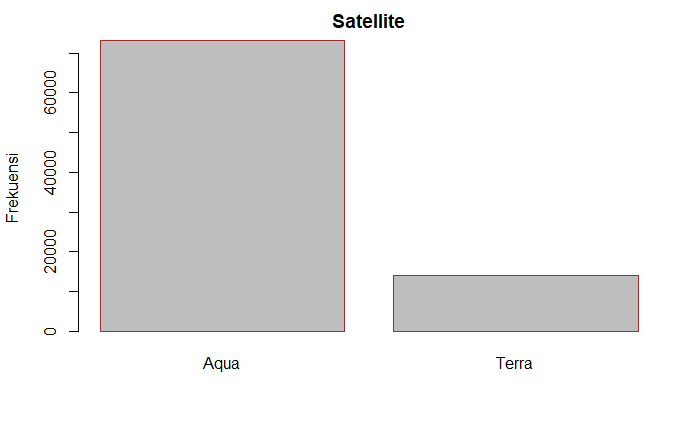

```r
barplot(jumlah, main='Satellite', ylab='Frekuensi', border = "brown",
)
```

```r
jumlah <- table(data_modis_new$daynight)
persentase <- 100*table(data_modis_new$daynight)/nrow(data_modis_new)
df <- data.frame(jumlah_sampel=jumlah, persentase=round(persentase, 1))
print(df)
```

| jumlah_sampel.Var1 | jumlah_sampel.Freq | persentase.Var1 | persentase.Freq |
| --- | --- | --- | --- |
| D | 84398 | D | 96.7 |
| N | 2884 | N | 3.3 |

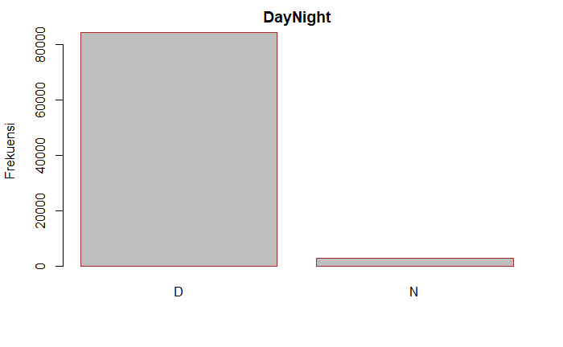

```r
barplot(jumlah, main='DayNight', ylab='Frekuensi', border = "brown",
)
```

Berdasarkan deskripsi variabel DayNigth, diketahui pengamatan titik api banyak diperoleh pada siang hari (Day), dengan persentase sebesar 96.7%.

```r
jumlah <- table(data_modis_new$type)
persentase <- 100*table(data_modis_new$type)/nrow(data_modis_new)
df <- data.frame(jumlah_sampel=jumlah, persentase=round(persentase, 1))
print(df)
```

| jumlah_sampel.Var1 | jumlah_sampel.Freq | persentase.Var1 | persentase.Freq |
| --- | --- | --- | --- |
| 0 | 87190 | 0 | 99.9 |
| 1 | 5 | 1 | 0.0 |
| 2 | 42 | 2 | 0.0 |
| 3 | 45 | 3 | 0.1 |

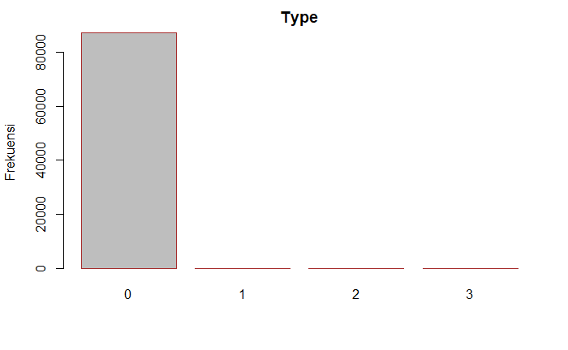

```r
barplot(jumlah, main='Type', ylab='Frekuensi', border = "brown",
)
```

Berdasarkan informasi dari deskripsi variabel Type di atas, data titik api yang terdapat dalam dataset MODIS 99.9% atau 87190 observasi diantaranya diduga merupakan kebakaran vegetasi (tipe 0), diikuti dengan 45 observasi diduga deteksi lepas pantai (tipe 3), 42 observasi diduga sumber tanah staits lainnya (tipe 2), dan 5 observasi diduga gunung berapi aktif (tipe 1).

Untuk fitur numerik, dapat dilihat histogram masing-masing fitur sebagai berikut.

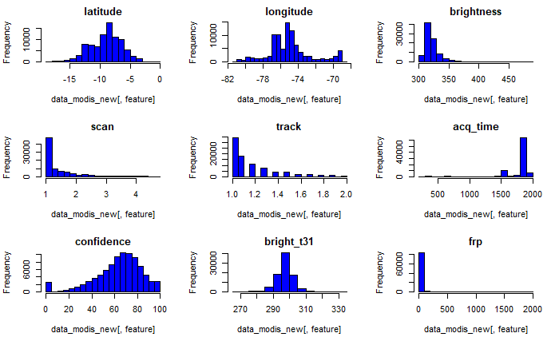

```r
# Menentukan fitur numerik
numeric_features <- sapply(data_modis_new, is.numeric)

# Memplot semua fitur numerik dalam grid histogram
par(mfrow=c(3,3)) # Menetapkan layout grid 4x4
for (feature in names(data_modis_new)[numeric_features]) {
  hist(data_modis_new[,feature], main=feature, col="blue")
}
```

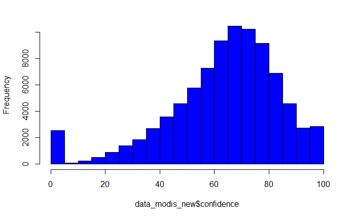

```r
hist(data_modis_new$confidence, main="", col="blue")
```

Berdasarkan histogram di atas, dapat diperoleh informasi diantaranya:

- Peningkatan nilai brightness, scan, track, dan frp sebanding dengan penurunan jumlah sampel. Hal ini dapat dilihat dari histogram masing-masing variabel tersebut yang grafiknya mengalami penurunan seiring dengan semakin besarnya nilai variabel.
- Lebih dari setengah nilai confidence bernilai di atas 50.

## B.4 Multivariate Analysis

Pada tahapan ini, dilakukan pengamatan terhadap hubungan antarfitur numerik. Selain itu, dilakukan observasi korelasi.

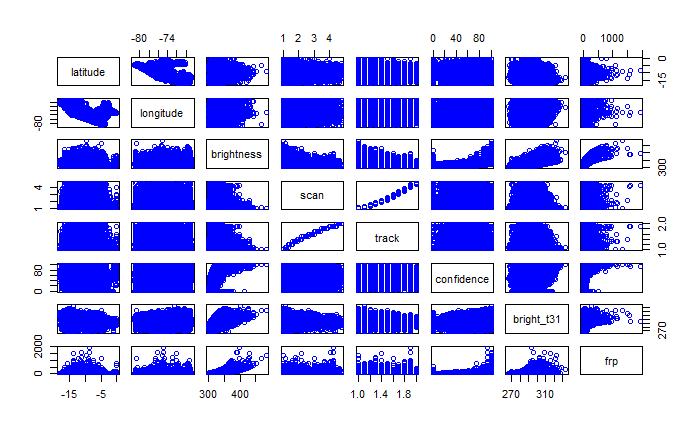

Fungsi `pairs` pada R menunjukkan relasi pasangan dalam dataset. Korelasi pada fitur tampak dari adanya pola pada sebaran data. Sebaran data acak merupakan indikasi korelasi yang lemah (atau tidak ada korelasi sama sekali), sedangkan sebaran data yang memiliki pola (tidak acak) merupakan indikasi adanya korelasi. Pada pola sebaran data grafik di atas, terlihat adanya korelasi positif antara variabel “scan” dan “track”. Korelasi positif ditandai dengan meningkatnya variabel pada sumbu y saat terjadi peningkatan variabel pada sumbu x. Selain itu, terlihat variabel “brightness” memiliki korelasi positif dengan variabel “frs”. Korelasi juga terlihat antara variabel “brightness” dengan “bright_t31”

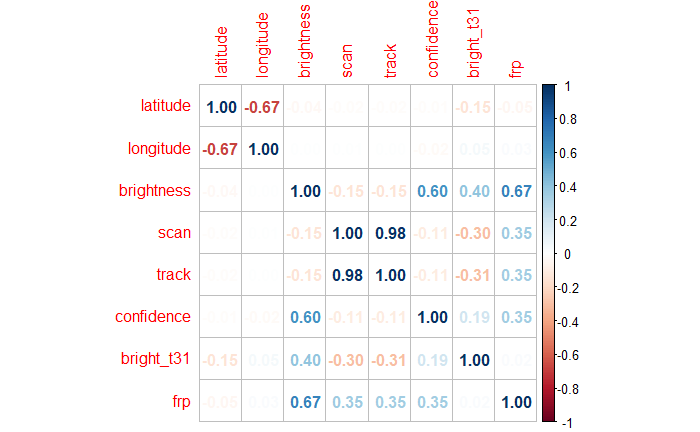

```r
matriks_korelasi <- cor(data_modis_new[c('latitude', 'longitude', 'brightness', 'scan', 'track', 'confidence', 'bright_t31', 'frp')])

corrplot(matriks_korelasi, method="number", sig.level=0.05,  tl.cex=1)
```

Koefisien korelasi berkisar antara -1 dan +1. Koefisien ini mengukur kekuatan hubungan antara dua variabel serta arahnya (positif atau negatif). Semakin dekat nilainya ke 1 atau -1, korelasinya semakin kuat. Sedangkan semakin dekat nilainya ke 0, korelasinya semakin lemah. Korelasi positif berarti nilai kedua variabel cenderung meningkat bersama-sama, sedangkan korelasi negatif berarti nilai salah satu variabel cenderung meningkat ketika nilai variabel lainnya menurun. Pada grafik di atas, nilai korelasi positif yang besar terlihat antara variabel brightness dengan confidence, brightness dengan frp. Di sisi lain, korelasi negatif yang besar terlihat antara variabel latitude dan longitude.

# C. Preprocessing

Pada tahapan preprocessing, dilakukan serangkaian proses transformasi pada data sehingga menjadi bentuk yang cocok untuk proses analisis PCA nantinya.

Sebelumnya, diketahui bahwa variabel “version” dan “instrument” hanya memiliki satu nilai unik, yaitu “6.2” untuk version dan “MODIS” untuk instrument. Maka dari itu, variabel ini tidak diikutkan karena tidak memberikan informasi yang berarti dalam proses analisis. Maka dari itu, variabel “version” dan “instrumen” akan dihapus dari dataset.

```r
# menghapus variabel dari dataset
data_modis_prep <- data_modis_new[,!names(data_modis_new) %in% c("version", "instrument")]
str(data_modis_prep)
```

```
'data.frame':   87282 obs. of  13 variables:
 $ latitude  : num  -8.98 -8.98 -6.45 -6.45 -6.87 ...
 $ longitude : num  -74.7 -74.7 -76.9 -76.9 -76.1 ...
 $ brightness: num  300 301 303 304 301 ...
 $ scan      : num  1 1 1 1 1 1.1 3.2 3.2 2.5 3.2 ...
 $ track     : num  1 1 1 1 1 1.1 1.7 1.7 1.5 1.7 ...
 $ acq_date  : Date, format: "2010-01-01" "2010-01-01" "2010-01-01" "2010-01-01" ...
 $ acq_time  : int  338 338 339 339 641 641 1603 1603 1603 1603 ...
 $ satellite : Factor w/ 2 levels "Aqua","Terra": 2 2 2 2 1 1 2 2 2 2 ...
 $ confidence: int  16 31 39 53 34 62 61 60 30 75 ...
 $ bright_t31: num  280 280 291 292 282 ...
 $ frp       : num  4.2 4.6 4.9 5.4 5 ...
 $ daynight  : Factor w/ 2 levels "D","N": 2 2 2 2 2 2 1 1 1 1 ...
 $ type      : Factor w/ 4 levels "0","1","2","3": 1 1 1 1 1 1 1 1 1 1 ...
```

## C.1 Encoding Fitur Kategori

Proses encoding akan menghasilkan fitur baru yang sesuai sehingga dapat mewakili variabel kategori.Pada dataset MODIS Peru 2010-2015 yang penulis gunakan, variabel “satellite” dan “daynight” merupakan variabel bertipe kategorik yang hanya memiliki 2 nilai kategori. Metode encoding yang dapat digunakan ialah dummy coding. Karena hanya ada satu atribut yang dikodekan sebagai 1 dan yang lainnya sudah pasti 0, dummy encoding dikenal juga sebagai one-hot encoding (Lantz, 2019). Pada metode ini, nilai 1 mewakili sebuah kategori, dan 0 mewaliki kategori lainnya. Tidak perlu membuat variabel baru untuk kategori lainnya karena keduanya mutually exclusive, mengetahui salah satunya saja sudah cukup. Aspek yang nyaman dari pengkodean dummy adalah bahwa jarak antara fitur yang dikodekan dummy selalu satu atau nol, dan dengan demikian, nilainya jatuh pada skala yang sama dengan data numerik min-max yang dinormalisasi. Tidak diperlukan transformasi tambahan.

```r
# Memencode fitur satellite dan daynight menggunakan 0 dan 1
data_modis_prep$satellite  <- ifelse(data_modis_prep$satellite=="Aqua", 0, 1)
data_modis_prep$daynight  <- ifelse(data_modis_prep$daynight=="D", 0, 1)
str(data_modis_prep)
```

```
'data.frame':   87282 obs. of  13 variables:
 $ latitude  : num  -8.98 -8.98 -6.45 -6.45 -6.87 ...
 $ longitude : num  -74.7 -74.7 -76.9 -76.9 -76.1 ...
 $ brightness: num  300 301 303 304 301 ...
 $ scan      : num  1 1 1 1 1 1.1 3.2 3.2 2.5 3.2 ...
 $ track     : num  1 1 1 1 1 1.1 1.7 1.7 1.5 1.7 ...
 $ acq_date  : Date, format: "2010-01-01" "2010-01-01" "2010-01-01" "2010-01-01" ...
 $ acq_time  : int  338 338 339 339 641 641 1603 1603 1603 1603 ...
 $ satellite : num  1 1 1 1 0 0 1 1 1 1 ...
 $ confidence: int  16 31 39 53 34 62 61 60 30 75 ...
 $ bright_t31: num  280 280 291 292 282 ...
 $ frp       : num  4.2 4.6 4.9 5.4 5 ...
 $ daynight  : num  1 1 1 1 1 1 0 0 0 0 ...
 $ type      : Factor w/ 4 levels "0","1","2","3": 1 1 1 1 1 1 1 1 1 1 ...
```

Selain itu, juga terdapat variabel “type” yang memiliki 4 nilai kategori yang unik, yang mewakili 4 tipe titik api. Untuk mengencode data ini, digunakan metode label encoding yang merepresentasikan tiap kategori dalam nilai numerik [[AnalyticsVidia](https://www.analyticsvidhya.com/blog/2020/03/one-hot-encoding-vs-label-encoding-using-scikit-learn/)]. Nilai yang mewakili tiap tipe sesuai dengan nomor tipenya masing-masing, yaitu 0, 1, 2, dan 3.

```r
#type_encoded <- model.matrix(~ type - 1, data=data_modis_prep)
#data_modis_prep <- data.frame(data_modis_prep, type_encoded)
#data_modis_prep <- data_modis_prep[,!names(data_modis_prep) %in% c("type")]

data_modis_prep$type <- as.numeric(data_modis_prep$type)
str(data_modis_prep)
```

```
'data.frame':   87282 obs. of  13 variables:
 $ latitude  : num  -8.98 -8.98 -6.45 -6.45 -6.87 ...
 $ longitude : num  -74.7 -74.7 -76.9 -76.9 -76.1 ...
 $ brightness: num  300 301 303 304 301 ...
 $ scan      : num  1 1 1 1 1 1.1 3.2 3.2 2.5 3.2 ...
 $ track     : num  1 1 1 1 1 1.1 1.7 1.7 1.5 1.7 ...
 $ acq_date  : Date, format: "2010-01-01" "2010-01-01" "2010-01-01" "2010-01-01" ...
 $ acq_time  : int  338 338 339 339 641 641 1603 1603 1603 1603 ...
 $ satellite : num  1 1 1 1 0 0 1 1 1 1 ...
 $ confidence: int  16 31 39 53 34 62 61 60 30 75 ...
 $ bright_t31: num  280 280 291 292 282 ...
 $ frp       : num  4.2 4.6 4.9 5.4 5 ...
 $ daynight  : num  1 1 1 1 1 1 0 0 0 0 ...
 $ type      : num  1 1 1 1 1 1 1 1 1 1 ...
```

## C.2 Transformasi Data Date acq_date

Agar informasi yang ada dalam variabel acq_date dan acq_time dapat ikut diolah, maka variabel tersebut perlu diubah ke dalam tipe data numerik dengan menggunakan fungsi `as.numeric()`. Namun, pertama-tama data tanggal dan jam perlu digabungkan terlebih dahulu, baru kemudian di ubah kedalam integer. Fungsi akan mengembalikan jumlah detik yang telah berlalu sejak tanggal 1/1/1970 (penanggalan awal pada Unix).

```r
# Mengubah format time ke jam:menit
temp <- data_modis_prep$acq_time
temp2 <- mapply(function(x, y) paste0(rep(x, y), collapse = ""), 0, 4 - nchar(temp))
temp <- paste0(temp2, temp)
data_modis_prep$acq_time <- format(strptime(temp, format="%H%M"), format = "%H:%M")

# Menggabungkan data tanggal dan jam, lalu konversi ke waktu Unix
datetime <- paste0(data_modis_prep$acq_date, " ", data_modis_prep$acq_time)
datetime2 <- as.POSIXct(datetime)
datetime3 <- as.numeric(datetime2)
head(datetime3)
```

```
[1] 1262291880 1262291880 1262291940 1262291940 1262302860 1262302860
```

```r
# Mengubah nilai data tanggal menjadi datetime, lalu menghapus kolom jam
data_modis_prep$acq_datetime <- datetime3
data_modis_prep <- data_modis_prep[,!names(data_modis_prep) %in% c("acq_time", "acq_date")]
str(data_modis_prep)
```

```
'data.frame':   87282 obs. of  12 variables:
 $ latitude    : num  -8.98 -8.98 -6.45 -6.45 -6.87 ...
 $ longitude   : num  -74.7 -74.7 -76.9 -76.9 -76.1 ...
 $ brightness  : num  300 301 303 304 301 ...
 $ scan        : num  1 1 1 1 1 1.1 3.2 3.2 2.5 3.2 ...
 $ track       : num  1 1 1 1 1 1.1 1.7 1.7 1.5 1.7 ...
 $ satellite   : num  1 1 1 1 0 0 1 1 1 1 ...
 $ confidence  : int  16 31 39 53 34 62 61 60 30 75 ...
 $ bright_t31  : num  280 280 291 292 282 ...
 $ frp         : num  4.2 4.6 4.9 5.4 5 ...
 $ daynight    : num  1 1 1 1 1 1 0 0 0 0 ...
 $ type        : num  1 1 1 1 1 1 1 1 1 1 ...
 $ acq_datetime: num  1.26e+09 1.26e+09 1.26e+09 1.26e+09 1.26e+09 ...
```

Hasil dari proses ini memiliki deskripsi sebagai berikut

```r
describe(data_modis_prep)
```

|  | vars | n | mean | sd | median | trimmed | mad | min | max | range | skew | kurtosis | se |
| --- | --- | --- | --- | --- | --- | --- | --- | --- | --- | --- | --- | --- | --- |
| latitude | 1 | 87282 | -9.07 | 2.57 | -8.83 | -8.99 | 2.60 | -18.14 | -0.03 | 18.10 | -0.34 | 0.04 | 0.01 |
| longitude | 2 | 87282 | -75.06 | 2.42 | -75.19 | -75.22 | 1.71 | -81.26 | -68.77 | 12.49 | 0.61 | 0.78 | 0.01 |
| brightness | 3 | 87282 | 321.77 | 12.27 | 318.90 | 320.05 | 8.30 | 300.00 | 485.20 | 185.20 | 2.28 | 9.68 | 0.04 |
| scan | 4 | 87282 | 1.51 | 0.73 | 1.20 | 1.35 | 0.30 | 1.00 | 4.80 | 3.80 | 2.09 | 4.36 | 0.00 |
| track | 5 | 87282 | 1.18 | 0.23 | 1.10 | 1.14 | 0.15 | 1.00 | 2.00 | 1.00 | 1.49 | 1.68 | 0.00 |
| satellite | 6 | 87282 | 0.16 | 0.37 | 0.00 | 0.08 | 0.00 | 0.00 | 1.00 | 1.00 | 1.85 | 1.42 | 0.00 |
| confidence | 7 | 87282 | 64.07 | 20.35 | 67.00 | 65.83 | 17.79 | 0.00 | 100.00 | 100.00 | -0.97 | 1.31 | 0.07 |
| bright_t31 | 8 | 87282 | 297.22 | 5.35 | 297.50 | 297.35 | 4.00 | 265.90 | 333.50 | 67.60 | -0.39 | 3.10 | 0.02 |
| frp | 9 | 87282 | 27.81 | 41.91 | 16.20 | 20.06 | 11.86 | 0.00 | 1928.30 | 1928.30 | 9.94 | 211.89 | 0.14 |
| daynight | 10 | 87282 | 0.03 | 0.18 | 0.00 | 0.00 | 0.00 | 0.00 | 1.00 | 1.00 | 5.22 | 25.30 | 0.00 |

[output cut: 2 more lines]

```r
head(data_modis_prep)
```

|  | latitude | longitude | brightness | scan | track | satellite | confidence | bright_t31 | frp | daynight | type | acq_datetime |
| --- | --- | --- | --- | --- | --- | --- | --- | --- | --- | --- | --- | --- |
| 1 | -8.9797 | -74.6893 | 300.1 | 1.0 | 1.0 | 1 | 16 | 280.0 | 4.2 | 1 | 1 | 1262291880 |
| 2 | -8.9783 | -74.6800 | 300.6 | 1.0 | 1.0 | 1 | 31 | 279.8 | 4.6 | 1 | 1 | 1262291880 |
| 3 | -6.4500 | -76.8717 | 303.2 | 1.0 | 1.0 | 1 | 39 | 290.9 | 4.9 | 1 | 1 | 1262291940 |
| 4 | -6.4487 | -76.8628 | 304.5 | 1.0 | 1.0 | 1 | 53 | 292.0 | 5.4 | 1 | 1 | 1262291940 |
| 5 | -6.8659 | -76.1315 | 300.8 | 1.0 | 1.0 | 0 | 34 | 282.1 | 5.0 | 1 | 1 | 1262302860 |
| 6 | -7.8374 | -75.0634 | 304.8 | 1.1 | 1.1 | 0 | 62 | 292.0 | 5.8 | 1 | 1 | 1262302860 |

# D. Number of Factors

Tahapan ini bertujuan untuk menentukan jumlah faktor/komponen yang akan diekstrak. Metode yang digunakan untuk menentukan jumlah faktor ini ialah dengan menginspeksi scree plot [[Warfell, 2015](https://www.dominodatalab.com/blog/how-to-do-factor-analysis)]

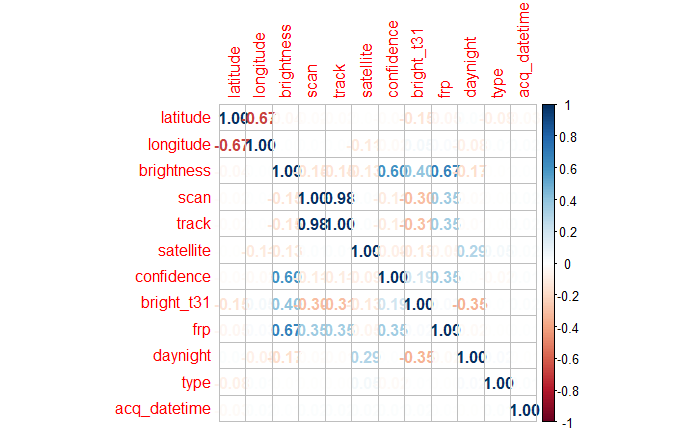

```r
matriks_korelasi <- cor(data_modis_prep)

corrplot(matriks_korelasi, method="number", sig.level=0.05,  tl.cex=1)
```

```r
NA
NA
```

```r
# sel Uji
data_modis_h <- data_modis_prep[,!names(data_modis_prep) %in% c(#"acq_datetime", "type"
                                                                #,"satellite"#, "daynight",
                                                                #,"type0","type1","type2","type3"
                                                                #,,
                                                                )]
str(data_modis_h)
```

```
'data.frame':   87282 obs. of  12 variables:
 $ latitude    : num  -8.98 -8.98 -6.45 -6.45 -6.87 ...
 $ longitude   : num  -74.7 -74.7 -76.9 -76.9 -76.1 ...
 $ brightness  : num  300 301 303 304 301 ...
 $ scan        : num  1 1 1 1 1 1.1 3.2 3.2 2.5 3.2 ...
 $ track       : num  1 1 1 1 1 1.1 1.7 1.7 1.5 1.7 ...
 $ satellite   : num  1 1 1 1 0 0 1 1 1 1 ...
 $ confidence  : int  16 31 39 53 34 62 61 60 30 75 ...
 $ bright_t31  : num  280 280 291 292 282 ...
 $ frp         : num  4.2 4.6 4.9 5.4 5 ...
 $ daynight    : num  1 1 1 1 1 1 0 0 0 0 ...
 $ type        : num  1 1 1 1 1 1 1 1 1 1 ...
 $ acq_datetime: num  1.26e+09 1.26e+09 1.26e+09 1.26e+09 1.26e+09 ...
```

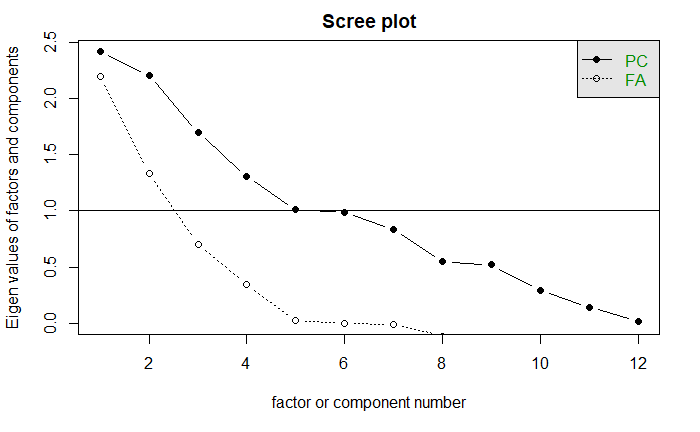

```r
scree(data_modis_h)
```

```
Parallel analysis suggests that the number of factors =  5  and the number of components =  5
```

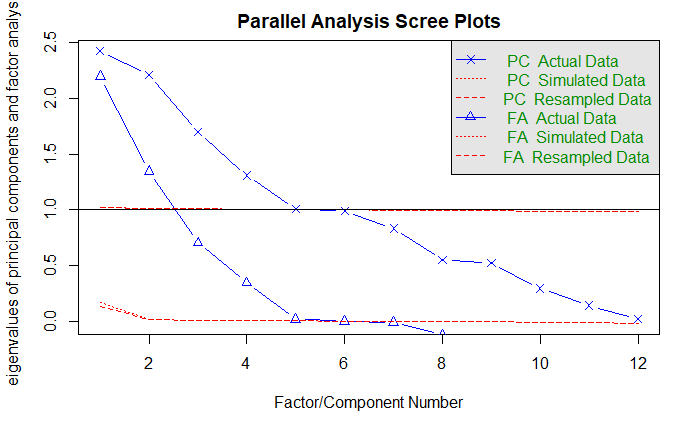

```r
fa.parallel(data_modis_h, fm='mle')
```

```r
print(fa(data_modis_h, 5, fm='mle',rotate='oblimin')$loadings,cut=.2)
```

```
Loadings:
             ML1    ML3    ML2    ML4    ML5
latitude                    0.998
longitude                  -0.685        -0.221
brightness           0.958
scan          0.998
track         0.983
satellite                          0.485
confidence           0.598
bright_t31                        -0.268  0.524
frp           0.295  0.778
daynight                           0.665
type
acq_datetime

                 ML1   ML3   ML2   ML4   ML5
SS loadings    2.107 1.907 1.482 0.804 0.419
Proportion Var 0.176 0.159 0.123 0.067 0.035
Cumulative Var 0.176 0.335 0.458 0.525 0.560
```

[figure not shown]

Pada scree plot, setiap faktor atau komponen tambahan hanya akan menghasilkan pengurangan nilai eigen secara marjinal setelah titik tertentu. Pengurangan yang tidak signifikan akan memberikan gambaran semacam ‘siku’ yang dihasilkan oleh grafik. Dengan mengikuti metode “Elbow Rule”, didapatkan angka “5” sebagai angka tertinggi yang memenuhi, yang merupakan titik di mana nilai varians masih berkurang secara signifikan.

Cara lain yang dapat digunakan untuk memeriksa ulang jumlah faktor yang akan diekstrak ialah menggunakan analisis paralel. Analisis pararel dalam [The Journal of Vegetaion Science](http://opensiuc.lib.siu.edu/cgi/viewcontent.cgi?article=1004&context=pb_pubs) dideskripsikan sebagai berikut: Dalam parallel analysis, nilai eigen dari sebuah data sebelum rotasi dibandingkan dengan nilai eigen dari matriks nilai acak dengan dimensi yang sama (p variabel dan n sampel). Tujuan dari perbandingan ini adalah untuk menentukan nilai eigen mana yang tidak signifikan dibandingkan dengan nilai eigen yang dihasilkan secara acak. Nilai eigen yang dianggap tidak signifikan adalah nilai eigen yang berada di bawah nilai eigen yang dihasilkan secara acak.

```
Parallel analysis suggests that the number of factors =  5  and the number of components =  5
```

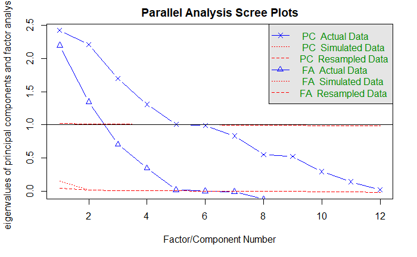

```r
fa.parallel(data_modis_prep, fm='ml')
```

Berdasrakan kode tersebut, paralel analysis menyarankan jumlah faktor bernilai 5 dan jumlah komponen bernilai 5. Pada kode tersebut, metode yang digunakan untuk estimasi skor faktor adalah “Maximum Likelihood” yang ditandai dengan parameter fm=“ml”.

Dalam proses factor analysis, akan dilakukan interpretasi terhadap Rotation. Rotasi dapat dikategorikan menjadi dua, ortogonal dan oblique. Rotasi ortogonal mengasumsikan bahwa faktor-faktor yang ada tidak berkorelasi, sedangkan rotasi oblique mengasumsikan bahwa faktor-faktor tersebut berkorelasi. Dua jenis rotasi yang populer adalah Varimax (ortogonal), dan Oblimin (miring). Pada tahapan analisis ini, penulis menggunakan rotasi oblimin. [Warfel, 2015](https://www.dominodatalab.com/blog/how-to-do-factor-analysis)

```r
fa(data_modis_prep, 5, fm='ml', rotate='oblimin')
```

```
Factor Analysis using method =  ml
Call: fa(r = data_modis_prep, nfactors = 5, rotate = "oblimin", fm = "ml")
Standardized loadings (pattern matrix) based upon correlation matrix
```

|  | ML1 | ML3 | ML2 | ML4 | ML5 | h2 | u2 | com |
| --- | --- | --- | --- | --- | --- | --- | --- | --- |
| latitude | -0.03 | 0.00 | 1.00 | -0.06 | -0.08 | 0.995000060 | 0.004999940 | 1.021676 |
| longitude | -0.07 | -0.01 | -0.69 | -0.18 | -0.22 | 0.537280265 | 0.462719735 | 1.375238 |
| brightness | -0.13 | 0.96 | 0.01 | -0.06 | 0.08 | 0.995008406 | 0.004991594 | 1.056354 |
| scan | 1.00 | -0.01 | 0.00 | -0.01 | 0.00 | 0.994484574 | 0.005515426 | 1.000446 |
| track | 0.98 | -0.01 | 0.00 | -0.01 | -0.01 | 0.968316227 | 0.031683773 | 1.000431 |
| satellite | 0.05 | -0.06 | -0.02 | 0.48 | 0.19 | 0.229926040 | 0.770073960 | 1.352377 |
| confidence | -0.10 | 0.60 | 0.01 | 0.08 | 0.05 | 0.369733138 | 0.630266862 | 1.107679 |
| bright_t31 | -0.10 | 0.15 | -0.09 | -0.27 | 0.52 | 0.557470419 | 0.442529581 | 1.864791 |
| frp | 0.29 | 0.78 | -0.02 | 0.05 | -0.13 | 0.704044179 | 0.295955821 | 1.357689 |
| daynight | -0.11 | 0.02 | -0.03 | 0.66 | -0.14 | 0.494477653 | 0.505522347 | 1.152130 |

[output cut: 2 more lines]

```
                       ML1  ML3  ML2  ML4  ML5
SS loadings           2.13 1.92 1.49 0.84 0.48
Proportion Var        0.18 0.16 0.12 0.07 0.04
Cumulative Var        0.18 0.34 0.46 0.53 0.57
Proportion Explained  0.31 0.28 0.22 0.12 0.07
Cumulative Proportion 0.31 0.59 0.81 0.93 1.00

 With factor correlations of
      ML1   ML3   ML2   ML4   ML5
ML1  1.00  0.01 -0.01  0.07 -0.36
ML3  0.01  1.00 -0.04 -0.17  0.18
ML2 -0.01 -0.04  1.00  0.09 -0.03
ML4  0.07 -0.17  0.09  1.00 -0.27
ML5 -0.36  0.18 -0.03 -0.27  1.00

Mean item complexity =  1.5
Test of the hypothesis that 5 factors are sufficient.

The degrees of freedom for the null model are  66  and the objective function was  6.12 with Chi Square of  533821.2
The degrees of freedom for the model are 16  and the objective function was  0.04

The root mean square of the residuals (RMSR) is  0.01
The df corrected root mean square of the residuals is  0.02

The harmonic number of observations is  87282 with the empirical chi square  1716.78  with prob <  0
The total number of observations was  87282  with Likelihood Chi Square =  3228.29  with prob <  0

Tucker Lewis Index of factoring reliability =  0.975
RMSEA index =  0.048  and the 90 % confidence intervals are  0.047 0.049
BIC =  3046.26
Fit based upon off diagonal values = 1
Measures of factor score adequacy
                                                   ML1  ML3  ML2  ML4  ML5
Correlation of (regression) scores with factors   1.00 1.00 1.00 0.79 0.75
Multiple R square of scores with factors          1.00 0.99 0.99 0.62 0.56
Minimum correlation of possible factor scores     0.99 0.98 0.98 0.23 0.12
```

Berdasarkan output di atas, terlihat nilai RMSEA index sebesar 0.048. Nilai ini sudah memenuhi rule of thumb, di mana rule of thumb standard dari nilai RMSEA index ialah kurang dari .06.

```r
print(fa(data_modis_prep, 5, fm='ml',rotate='oblimin')$loadings,cut=.2)
```

```
Loadings:
             ML1    ML3    ML2    ML4    ML5
latitude                    0.998
longitude                  -0.685        -0.221
brightness           0.958
scan          0.998
track         0.983
satellite                          0.485
confidence           0.598
bright_t31                        -0.268  0.524
frp           0.295  0.778
daynight                           0.665
type
acq_datetime

                 ML1   ML3   ML2   ML4   ML5
SS loadings    2.107 1.907 1.482 0.804 0.419
Proportion Var 0.176 0.159 0.123 0.067 0.035
Cumulative Var 0.176 0.335 0.458 0.525 0.560
```

Selanjutnya, dilakukan pengamatan terhadap faktor terakhir. Pada faktor ML5, nilai loadings yang dihasilkan tidak ada yang tinggi, yang menandakan bahwa faktor tersebut tidak penting. Untuk itu, dilakukan pengujian untuk nilai faktor=4.

```r
fa(modis_standardized, 4, fm='ml', 'oblimin')
```

```
Factor Analysis using method =  ml
Call: fa(r = modis_standardized, nfactors = 4, n.obs = "oblimin", fm = "ml")
Standardized loadings (pattern matrix) based upon correlation matrix
```

|  | ML3 | ML1 | ML2 | ML4 | h2 | u2 | com |
| --- | --- | --- | --- | --- | --- | --- | --- |
| latitude | 0.00 | 0.00 | 1.00 | -0.03 | 0.995001228 | 0.004998772 | 1.001394 |
| longitude | 0.00 | -0.04 | -0.67 | -0.06 | 0.459439933 | 0.540560067 | 1.024588 |
| brightness | -0.12 | 0.97 | 0.01 | -0.07 | 0.995011209 | 0.004988791 | 1.044336 |
| scan | 1.00 | -0.01 | 0.00 | -0.02 | 0.990595798 | 0.009404202 | 1.000894 |
| track | 0.99 | -0.01 | 0.00 | -0.02 | 0.972060557 | 0.027939443 | 1.000796 |
| satellite | -0.01 | -0.05 | -0.02 | 0.34 | 0.120531753 | 0.879468247 | 1.059983 |
| confidence | -0.10 | 0.61 | 0.01 | 0.08 | 0.371931008 | 0.628068992 | 1.089952 |
| bright_t31 | -0.28 | 0.26 | -0.13 | -0.38 | 0.370327825 | 0.629672175 | 2.934872 |
| frp | 0.36 | 0.75 | -0.01 | 0.09 | 0.678120951 | 0.321879049 | 1.477704 |
| daynight | -0.08 | 0.02 | -0.02 | 0.83 | 0.684426847 | 0.315573153 | 1.018384 |

[output cut: 2 more lines]

```
                       ML3  ML1  ML2  ML4
SS loadings           2.21 1.96 1.48 1.00
Proportion Var        0.18 0.16 0.12 0.08
Cumulative Var        0.18 0.35 0.47 0.55
Proportion Explained  0.33 0.30 0.22 0.15
Cumulative Proportion 0.33 0.63 0.85 1.00

 With factor correlations of
      ML3   ML1   ML2   ML4
ML3  1.00 -0.01 -0.01  0.09
ML1 -0.01  1.00 -0.04 -0.16
ML2 -0.01 -0.04  1.00  0.06
ML4  0.09 -0.16  0.06  1.00

Mean item complexity =  1.3
Test of the hypothesis that 4 factors are sufficient.

The degrees of freedom for the null model are  66  and the objective function was  6.12 with Chi Square of  533821.2
The degrees of freedom for the model are 24  and the objective function was  0.1

The root mean square of the residuals (RMSR) is  0.02
The df corrected root mean square of the residuals is  0.04

The harmonic number of observations is  87282 with the empirical chi square  5728.86  with prob <  0
The total number of observations was  87282  with Likelihood Chi Square =  8976.72  with prob <  0

Tucker Lewis Index of factoring reliability =  0.954
RMSEA index =  0.065  and the 90 % confidence intervals are  0.064 0.067
BIC =  8703.67
Fit based upon off diagonal values = 0.99
Measures of factor score adequacy
                                                   ML3  ML1  ML2  ML4
Correlation of (regression) scores with factors   1.00 1.00 1.00 0.85
Multiple R square of scores with factors          0.99 0.99 0.99 0.73
Minimum correlation of possible factor scores     0.99 0.99 0.99 0.46
```

Metriks yang dihasilkan untuk faktor = 4 tidak begitu buruk, meskipun nilai RMSEA index mencapai 0.065. Selanjutnya, dilakukan inspeksi faktor sebagai berikut.

```r
print(fa(modis_standardized, 4, fm='ml', rotate='oblimin')$loadings,cut=.2)
```

```
Loadings:
             ML3    ML1    ML2    ML4
latitude                    0.998
longitude                  -0.672
brightness           0.973
scan          0.997
track         0.987
satellite                          0.337
confidence           0.608
bright_t31   -0.277  0.262        -0.383
frp           0.362  0.749
daynight                           0.834
type
acq_datetime

                 ML3   ML1   ML2   ML4
SS loadings    2.208 1.952 1.473 0.981
Proportion Var 0.184 0.163 0.123 0.082
Cumulative Var 0.184 0.347 0.469 0.551
```

Pada tabel loading tersebut, terlihat bahwa variabel-variabel terkait dengan satu faktor utama. - variabel scan dan track berkolerasi positif kuat dengan faktor ML3

Dengan demikian jumlah faktor yang dapat digunakan untuk proses analisis selanjutnya adalah 4.

# E. Correlation Coefficient

```r
matriks_korelasi <- cor(data_modis_prep)
data.frame(matriks_korelasi)
```

|  | latitude | longitude | brightness | scan | track | satellite | confidence | bright_t31 | frp | daynight | type | acq_datetime |
| --- | --- | --- | --- | --- | --- | --- | --- | --- | --- | --- | --- | --- |
| latitude | 1.000000000 | -0.6709560539 | -0.0362236339 | -0.0183008566 | -0.0188977697 | -0.006445704 | -0.010368392 | -0.149043834 | -0.047160864 | 0.012006179 | -0.0752284493 | -0.027348948 |
| longitude | -0.670956054 | 1.0000000000 | 0.0007830883 | 0.0065166278 | 0.0032362291 | -0.114473514 | -0.022567944 | 0.048298023 | 0.026440292 | -0.075444253 | 0.0120116871 | 0.018097779 |
| brightness | -0.036223634 | 0.0007830883 | 1.0000000000 | -0.1485581407 | -0.1484804703 | -0.129343071 | 0.597290363 | 0.396560343 | 0.665781388 | -0.173030899 | -0.0070442295 | 0.008029237 |
| scan | -0.018300857 | 0.0065166278 | -0.1485581407 | 1.0000000000 | 0.9812942354 | 0.011927390 | -0.109622813 | -0.304492519 | 0.352561410 | -0.015665551 | -0.0008703368 | 0.017222452 |
| track | -0.018897770 | 0.0032362291 | -0.1484804703 | 0.9812942354 | 1.0000000000 | 0.010462548 | -0.107643244 | -0.308047938 | 0.346256410 | -0.014566347 | -0.0006228303 | 0.019902606 |
| satellite | -0.006445704 | -0.1144735136 | -0.1293430708 | 0.0119273898 | 0.0104625484 | 1.000000000 | -0.086677746 | -0.126213572 | -0.051767410 | 0.290307527 | 0.0464346502 | 0.016492722 |
| confidence | -0.010368392 | -0.0225679437 | 0.5972903626 | -0.1096228132 | -0.1076432435 | -0.086677746 | 1.000000000 | 0.192942881 | 0.345356709 | 0.008163499 | -0.0241328809 | 0.012889449 |
| bright_t31 | -0.149043834 | 0.0482980227 | 0.3965603435 | -0.3044925195 | -0.3080479378 | -0.126213572 | 0.192942881 | 1.000000000 | 0.022200924 | -0.345671874 | 0.0062281517 | 0.017099410 |
| frp | -0.047160864 | 0.0264402915 | 0.6657813880 | 0.3525614096 | 0.3462564098 | -0.051767410 | 0.345356709 | 0.022200924 | 1.000000000 | -0.023066556 | -0.0030868102 | 0.008103611 |
| daynight | 0.012006179 | -0.0754442532 | -0.1730308989 | -0.0156655514 | -0.0145663468 | 0.290307527 | 0.008163499 | -0.345671874 | -0.023066556 | 1.000000000 | 0.0249010430 | -0.005261417 |

[output cut: 2 more lines]

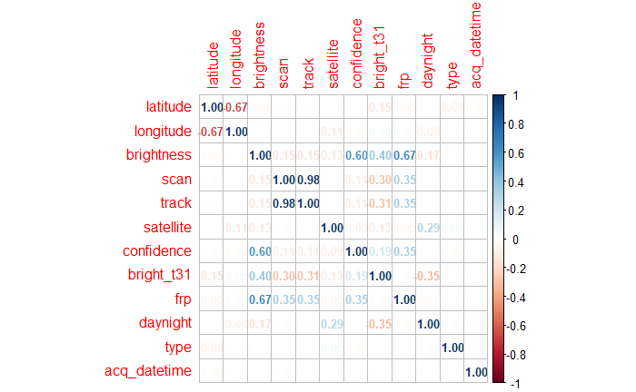

```r
corrplot(matriks_korelasi, method="number", sig.level=0.05,  tl.cex=1, addCoef.col = 1, number.cex = 0.8)
```

Berdasarkan hasil plot koefisien korelasi tersebut, dapat diketahui informasi sebagai berikut. - Terdapat korelasi positif yang kuat antara brightness dan frp. Hal ini ditandai dengan nilai positif 0.67 yang menunjukkan adanya hubungan positif. Artinya, jika brightness (temperatur kecerahan, dalam Kelvin) meningkat, maka fire radiative power juga cenderung meningkat, dan sebaliknya, jika brightness menurun, nilai kekuatan radiatif titik api juga cenderung menurun. Korelasi yang kuat dapat diartikan sebagai hubungan yang cukup kuat antara kedua variabel tersebut. Dengan - Terdapat korelasi yang kuat antara brightness dan confidence, dengan nilai 0.60. Artinya, jika brightness meningkat, confidence juga cenderung meningkat, dan sebaliknya, jika brightness menurun, frp juga cenderung menurun. Jadi, jika nilai temperatur kecerahan (dalam Kelvin) yang terdeteksi meningkat, besar kemungkinan nilai confidence/kepercayaannya juga besar.

- Terdapat korelasi yang sangat kuat terlihat antara variabel track dan scan, dengan nilai 0.98. Hal ini mungkin terjadi karena keduanya merupakan informasi tentang resolusi spasial dari pixel yang dipindai, yang saling terkait satu sama lain. Sebagai contoh, jika resolusi spasial di arah utara-selatan (track) meningkat, maka resolusi spasial di arah timur-barat (scan) juga mungkin akan meningkat, dan sebaliknya.
- Korelasi lainnya terlihat antara variabel brightness dan brigh_t31. Korelasi ini mungkin terjadi sebab keduanya sama-sama mengukur kecerahan, di mana variabel brightness mengukur temperatur kecerahan pada channel 21/22 dan 31, sedangkan temperatur bright_t31 mengukurnya pada channel 31 (sama-sama mengukur pada channel 31).
- Korelasi negatif yang kuat terlihat antara variabel latitude dan longitude. Hal ini dipengaruhi oleh kondisi geografis yang penulis analisis, yaitu negara Peru yang terletak di -12.433333, -77.283333.

# F. Scatter Plot hasil PCA

Principal Component Analysis dilakukan dengan menggunakan fungsi `prcomp`. Perlu diperhatikan bahwa normalisasi data merupakan hal yang penting untuk dilakukan sebelum melakukan PCA, sehingga perlu ditambahkan parameter scale = True. [[StackOverFlow](https://stats.stackexchange.com/questions/69157/why-do-we-need-to-normalize-data-before-principal-component-analysis-pca)].

```r
# Implementasi PCA
modis_peru_pca <- prcomp(data_modis_prep,
                   center = TRUE,
                   scale. = TRUE,)

summary(modis_peru_pca)
```

```
Importance of components:
                         PC1    PC2    PC3    PC4     PC5     PC6     PC7     PC8     PC9    PC10    PC11    PC12
Standard deviation     1.557 1.4865 1.3036 1.1437 1.00570 0.99399 0.91272 0.74181 0.72212 0.54263 0.37643 0.13635
Proportion of Variance 0.202 0.1841 0.1416 0.1090 0.08429 0.08234 0.06942 0.04586 0.04345 0.02454 0.01181 0.00155
Cumulative Proportion  0.202 0.3861 0.5278 0.6368 0.72104 0.80337 0.87279 0.91865 0.96210 0.98664 0.99845 1.00000
```

Untuk mengetahui variabel yang paling dominan dalam pembentukan principal component, penulis melihat matriks rotasi yang menunjukkan kontribusi masing-masing variabel terhadap setiap komponen utama. Setelah itu, urutkan kolom dari matriks tersebut berdasrakan nilai yang ada. Selanjutnya, dicari nilai indeks yang mengandung nilai terbesar dalam setiap komponen utama. Indeks kolom akan menunjukkan variabel apa yang paling banyak membentuk komponen utama.

```r
# Mengakses matriks rotasi
rotation <- modis_peru_pca$rotation
rotation
```

```
                       PC1          PC2         PC3         PC4           PC5          PC6         PC7         PC8
latitude     -0.0825167638  0.106057938 -0.65493045  0.23778253 -0.0439412469  0.010092325  0.08842221  0.09444797
longitude     0.0687214156 -0.090872247  0.66920046 -0.12852780  0.1380773314 -0.073395056  0.11063923  0.09741852
brightness    0.4353253819 -0.405154064 -0.16105325 -0.13036141  0.0002473607  0.019089570 -0.03631729  0.24688482
scan         -0.4633497317 -0.428988694  0.03677736  0.12472745 -0.0368184543  0.023148178 -0.09776487 -0.20914055
track        -0.4639709680 -0.427509419  0.03583845  0.12470545 -0.0384872613  0.021107700 -0.09346864 -0.21660686
satellite    -0.1519627060  0.123763992 -0.10271878 -0.52842335 -0.1136691305  0.007593473 -0.74384692  0.01248930
confidence    0.3392384311 -0.300236239 -0.18900974 -0.25084843  0.0749922552 -0.062040843  0.20826348 -0.69208445
bright_t31    0.4369167609 -0.040192019  0.08986806  0.22310478 -0.1622669483  0.067998390 -0.46414433 -0.28304886
frp           0.0776199297 -0.570871790 -0.12613207 -0.17312311  0.0288712176  0.020289190 -0.01040982  0.51091796
daynight     -0.1839080838  0.125739868 -0.12769259 -0.65319845  0.1487430362 -0.085710719  0.27850612 -0.09136126
type         -0.0089032761  0.009745923  0.08059421 -0.16869393 -0.6151350137  0.726492905  0.23428622 -0.01039526
acq_datetime  0.0004374628 -0.025955904  0.03999388 -0.04252305 -0.7279716294 -0.670138119  0.12510490  0.03511654
                       PC9          PC10         PC11          PC12
latitude      0.0858116328  0.6856523628  0.013641122 -5.272668e-03
longitude     0.1804825384  0.6660497516 -0.016181719 -5.412069e-03
brightness   -0.0060468101 -0.0076603245 -0.735158906  1.484439e-02
scan         -0.0871172029  0.0599043710 -0.118516643  7.098964e-01
track        -0.0839559007  0.0484822089 -0.150717202 -7.038709e-01
satellite     0.3101084881  0.0957806410 -0.004475161 -1.908947e-03
confidence    0.3491807974  0.0201384287  0.204855105 -9.265564e-05
bright_t31   -0.5904667098  0.2255055882  0.153577259 -6.759630e-03
frp          -0.0883085591 -0.0311411055  0.592249436 -1.677339e-02
daynight     -0.6079701595  0.1280717181 -0.077326206  9.513264e-04
type          0.0348751976  0.0495569292  0.004403501 -1.506134e-05
acq_datetime -0.0001337951 -0.0007392644  0.001357068  1.942734e-03
```

```r
# Mengetahui indeks kolom dengan nilai terbesar dalam setiap komponen utama, dimulai dari 0
variables <- apply(rotation, 2, which.max)
variables
```

```
 PC1  PC2  PC3  PC4  PC5  PC6  PC7  PC8  PC9 PC10 PC11 PC12
   8   10    2    1   10   11   10    9    7    1    9    4
```

```r
# Menentukan variabel apa yang paling banyak membentuk setiap komponen utama
important_variables <- names(data_modis_prep)[variables]
data.frame(PC=1:12, important_variables)
```

| PC | important_variables |
| --- | --- |
| 1 | bright_t31 |
| 2 | daynight |
| 3 | longitude |
| 4 | latitude |
| 5 | daynight |
| 6 | type |
| 7 | daynight |
| 8 | frp |
| 9 | confidence |
| 10 | latitude |

[output cut: 2 more lines]

```r
data.frame(sort(table(important_variables), decreasing = TRUE))
```

| important_variables | Freq |
| --- | --- |
| daynight | 3 |
| frp | 2 |
| latitude | 2 |
| bright_t31 | 1 |
| confidence | 1 |
| longitude | 1 |
| scan | 1 |
| type | 1 |

Hasil PCA dapat divisualisasikan menggunakan Scatter Plot, dengan hasil sebagai berikut

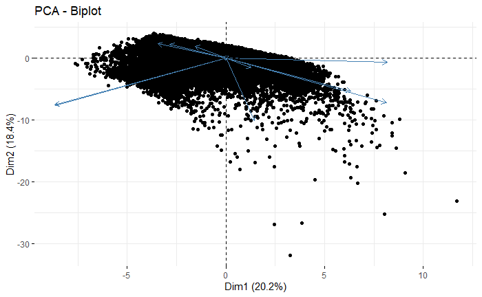

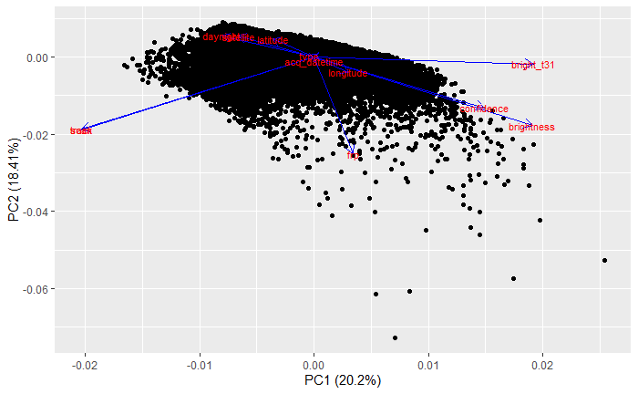

Berdasarkan hasil scatter plot PCA di atas, terlihat nilai loadings terkonsentrasi pada 4 arah utama, - track dan scan memuat kuat di faktor pertama

Sebelumnya, juga diketahui bahwa jumlah faktor utama yang baik adalah 4. Kita dapat mereduksi data yang awalnya terdiri dari 12 variabel menjadi 4 variabel namun tetap menggambarkan keragaman data

```r
data_modis_red <- modis_peru_pca$x[,1:4]
head(data_modis_red)
```

```
           PC1      PC2        PC3       PC4
[1,] -3.659061 3.515647 -0.4593555 -4.662684
[2,] -3.406710 3.273644 -0.6075548 -4.863225
[3,] -2.416843 3.169109 -1.7821580 -4.176685
[4,] -2.046342 2.904321 -1.9100984 -4.319537
[5,] -2.856127 3.004777 -1.2615624 -3.095932
[6,] -1.643512 2.046602 -0.8455050 -3.148216
```

Kita juga dapat mendapatkan hasil factor analysis menggunakan fungsi `factanal`.

[figure not shown]

```r
# Mengakses matriks rotasi. Rotation juga bisa disebut sebagai loadings, yaitu vektor eigen atau koeffisien dari masing-masing variabel yang digunakan untuk membentuk komponen utama
rotation_fa <- modis_peru_fa$loadings
rotation_fa
```

```
Loadings:
             Factor1 Factor2 Factor3 Factor4
latitude                     -0.994
longitude                     0.672
brightness   -0.125   0.959          -0.233
scan          0.994
track         0.985
satellite                             0.343
confidence            0.602
bright_t31   -0.293   0.263   0.126  -0.447
frp           0.367   0.738
daynight                              0.826
type
acq_datetime

               Factor1 Factor2 Factor3 Factor4
SS loadings      2.205   1.901   1.467   1.068
Proportion Var   0.184   0.158   0.122   0.089
Cumulative Var   0.184   0.342   0.464   0.553
```

```r
# Mengetahui indeks kolom dengan nilai terbesar dalam setiap komponen utama, dimulai dari 0
variables_fa <- apply(rotation_fa, 2, which.max)
variables_fa
```

```
Factor1 Factor2 Factor3 Factor4
      4       3       2      10
```

```r
# Menentukan variabel apa yang paling banyak membentuk setiap komponen utama
important_variables_fa <- names(data_modis_prep)[variables_fa]
data.frame(PC=1:4, important_variables_fa)
```

| PC | important_variables_fa |
| --- | --- |
| 1 | scan |
| 2 | brightness |
| 3 | longitude |
| 4 | daynight |

```r
data.frame(sort(table(important_variables_fa), decreasing = TRUE))
```

| important_variables_fa | Freq |
| --- | --- |
| brightness | 1 |
| daynight | 1 |
| longitude | 1 |
| scan | 1 |

Data hasil reduksi dimensi nantinya dapat digunakan untuk pembuatan model regresi.

# G. Fitting Model Diagram

Pada tahapan E, telah dilakukan analisi korelasi menggunakan matriks koefisien korelasi. Berdasarkan informasi tersebut, terdapat variabel yang memiliki korelasi yang sangat rendah, sehingga tidak akan diikutkan dalam proses pelatihan.Variabel-variabel yang tidak akan diikutkan dalam proses pelatihan tersebut diantaranya adalah type, acq_datetime, dan satellite.

Dataset akan dibagi ke dalam data train dan test dengan persentase 70:30. Target dari regresi ini adalah nilai FRP atau fire radiative power.

```r
set.seed(43) # agar reproducable

# Siapkan data yang akan digunakan untuk pelatihan
# data_modis_final <- data.frame(scale(data_modis_prep, scale = TRUE))

 # data_modis_prep[,!names(data_modis_prep) %in% c(#"type", "acq_datetime", "satellite"#,
                                                                    #"scan", "track"
                                                                #    )]

# Membagi data ke train dan test
train_percentage = 0.7
split <- sample(1:nrow(data_modis_final), size = floor(train_percentage * nrow(data_modis_final)))
modis_train <- data_modis_final[split, ]
modis_trainX <- modis_train[,!names(data_modis_prep) %in% c("frp")]
# Standarisasi fitur dilakukan pada data latih untuk menghasilkan distribusi standard
modis_trainX <- scale(modis_trainX, scale = TRUE)
modis_trainY <- modis_train[, c("frp")]
modis_train <- data.frame(modis_trainX, frp=modis_trainY)
modis_train
```

|  | latitude | longitude | brightness | scan | track | satellite | confidence | bright_t31 | daynight | type | acq_datetime | frp |
| --- | --- | --- | --- | --- | --- | --- | --- | --- | --- | --- | --- | --- |
| 10407 | -0.193007086 | 6.278096e-02 | -0.042549497 | -0.15630256 | 0.07618732 | -0.4374544 | -0.149559402 | 0.03394231 | -0.1853367 | -0.03123874 | -1.298942299 | -0.2292031494 |
| 82783 | -0.182834687 | -1.545423e-01 | 4.373939488 | 0.66590077 | 0.95445457 | -0.4374544 | 1.768602356 | -0.37756892 | -0.1853367 | -0.03123874 | 1.549911772 | 7.9138786717 |
| 79337 | -0.858889992 | 2.830943e-01 | -0.328274293 | -0.70443811 | -0.80207994 | -0.4374544 | -0.887313924 | -0.63943970 | -0.1853367 | -0.03123874 | 1.532954990 | -0.4296188755 |
| 73015 | -1.483849454 | 9.817014e-01 | -1.038504500 | -0.56740423 | -0.36294631 | 2.2859153 | -0.887313924 | -0.32145375 | -0.1853367 | -0.03123874 | 1.341380434 | -0.4940382160 |
| 57309 | 1.080218714 | -1.907746e+00 | 2.675917845 | -0.56740423 | -0.80207994 | -0.4374544 | 1.621051452 | 1.32459116 | -0.1853367 | -0.03123874 | 0.415648588 | 0.7108420418 |
| 66195 | -0.262421043 | -8.312634e-01 | 0.153376077 | -0.56740423 | -0.80207994 | -0.4374544 | 0.391460581 | 1.08142544 | -0.1853367 | -0.03123874 | 0.948072470 | -0.3795149439 |
| 10262 | 0.977520356 | -2.381824e-01 | -0.940541713 | 1.35107021 | 1.39358820 | -0.4374544 | -0.149559402 | -1.18188631 | -0.1853367 | -0.03123874 | -1.300530591 | -0.1934146269 |
| 10350 | 0.719234958 | -7.401480e-01 | -1.340556427 | -0.70443811 | -0.80207994 | 2.2859153 | -0.002008497 | -1.18188631 | 5.3954982 | -0.03123874 | -1.299926140 | -0.5202831325 |
| 2365 | 1.303154051 | -1.419652e+00 | -0.075203760 | -0.15630256 | 0.07618732 | -0.4374544 | 0.489827851 | 0.23969793 | -0.1853367 | -0.03123874 | -1.356061855 | -0.3317969139 |
| 43929 | 0.047155072 | -2.121020e-01 | 2.169776778 | -0.56740423 | -0.80207994 | -0.4374544 | 1.473500547 | 1.24977094 | -0.1853367 | -0.03123874 | -0.149206667 | 0.6464227013 |

[output cut: 990 more lines]

```r
modis_test <- data_modis_final[-split, ]
```

Selanjutnya, dilakukan pemodelan menggunaan metode regresi, sehingga akan dihasilkan diagram pelatihan model.

```r
# Modelling
# Melakukan training
linreg <- lm(frp ~ latitude+longitude+brightness+confidence+bright_t31+daynight+scan+track, data = modis_train)

# Melakukan testing
pred <- predict(linreg, modis_test)

data.frame(MAE = MAE(pred, modis_test$frp),
           RMSE = RMSE(pred, modis_test$frp),
           R2 = R2(pred, modis_test$frp))
```

| MAE | RMSE | R2 |
| --- | --- | --- |
| 0.2677017 | 0.5342913 | 0.7050433 |

```r
NA
```

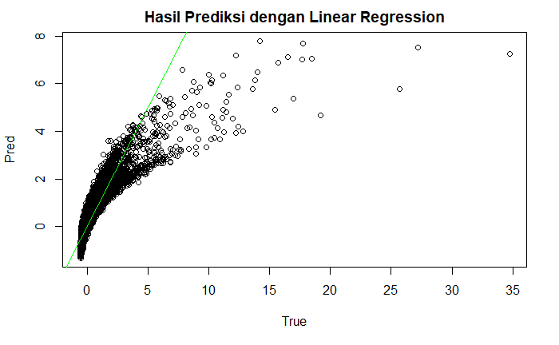

```r
plot(modis_test$frp, pred,
     xlab = "True", ylab = "Pred",
     main = "Hasil Prediksi dengan Linear Regression")
abline(a=0, b=1, col = "green")
```

# H. Cross Validation

Cross Validation digunakan untuk memvalidasi hasil pelatihan model regresi.

```r
# Inisialisasi objek train control cross validation
train_control <- trainControl(method = "cv", number = 10)

# Lakukan pelatihan dengan linear regression
linreg_cv <- train(frp ~ latitude+longitude+brightness+confidence+bright_t31+daynight+scan+track,
                   data = modis_train, method = "lm", trControl = train_control)

# Print the results
data.frame(nilai=t(linreg_cv$results))
```

|  | X1 |
| --- | --- |
| intercept | 1.000000000 |
| RMSE | 0.566956229 |
| Rsquared | 0.683170021 |
| MAE | 0.269992808 |
| RMSESD | 0.092737802 |
| RsquaredSD | 0.058322621 |
| MAESD | 0.005018694 |